# COMPSCIX 415.2 Homework 7

Inessa Wu

March 13, 2018

```r
library (tidyverse)
library (rmarkdown)
library (mosaicData)
library (lubridate)
library(broom)
```

### Exercise 1

Loading train.csv data set. Dataset contains 1460 observations and 81 variables (columns)

```r
file_path <- 'C:/Users/ipodvorna/Documents/compscix-415-2-assignments/compscix-415-2-assignments/train.csv'
housing_train_data <- read_delim(file = file_path, delim = ",")
```

### Exercise 2

Splitting data into training and test data sets (70/30)

```r
# Setting a seed to guarantee that the same random sample is
# generated every time, so long as the same seed is set beforehand

set.seed(29283)

# Creating training data set - 70% of data
train_set <- housing_train_data %>% sample_frac(.7)

# Assigning the remaining 30% of data to testing data set
test_set <- housing_train_data %>% filter(!(Id %in% train_set$Id))
```

### Exercise 3

```r
# Fit a model with intercept only
mod_0 <- lm(SalePrice ~ 1, data = train_set)

# The average SalePrice is equal to our model's coefficient at $182,176
mean(train_set$SalePrice)
```

```
## [1] 182176
```

```r
tidy(mod_0)
```

```
##          term estimate std.error statistic p.value
## 1 (Intercept)   182176  2492.072  73.10222       0
```

```r
# R-squared is 0
glance(mod_0)
```

```
##   r.squared adj.r.squared    sigma statistic p.value df    logLik      AIC
## 1         0             0 79668.37        NA      NA  1 -12983.57 25971.13
##        BIC     deviance df.residual
## 1 25980.99 6.480338e+12        1021
```

### Exercise 4

Before fitting the model:

1. What kind of relationship will these features have with our target?

Neighborhood: Physical locations within Ames city limits GrLivArea: Above grade (ground) living area square feet OverallQual: Overall material and finish quality

I expect GrLivArea and OverallQual to be directly correlated with the sales price. Neighborhood could be either directly or inversly correlated with the sales price, depending on the how good the neigborhood is perceived to be.

2. Can the relationship be estimated linearly?

Based on plots below, a linear realtionship could be estimated between sales price and GrLivArea as well as sales price and OverallQual

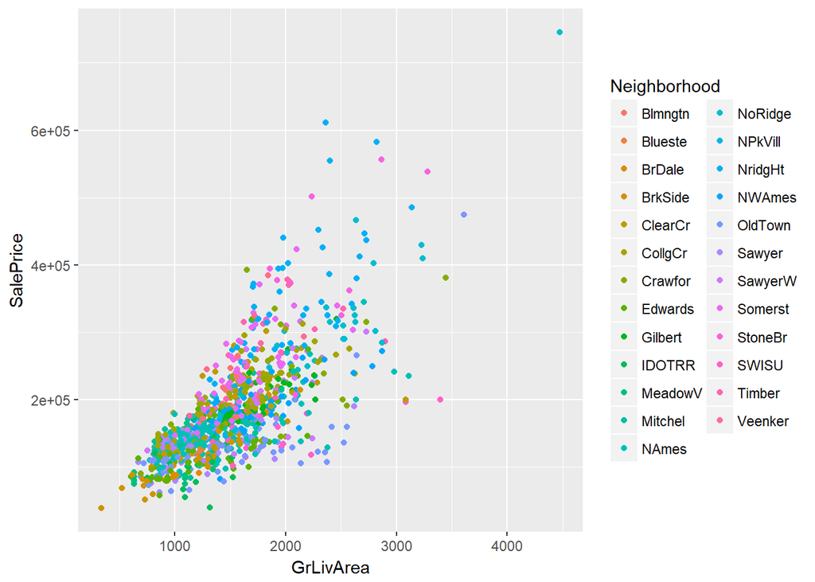

```r
# Plot relationship between sales price and GrLivArea

ggplot(data=train_set)+
  geom_point(mapping = aes(x=GrLivArea, y=SalePrice, color=Neighborhood))
```

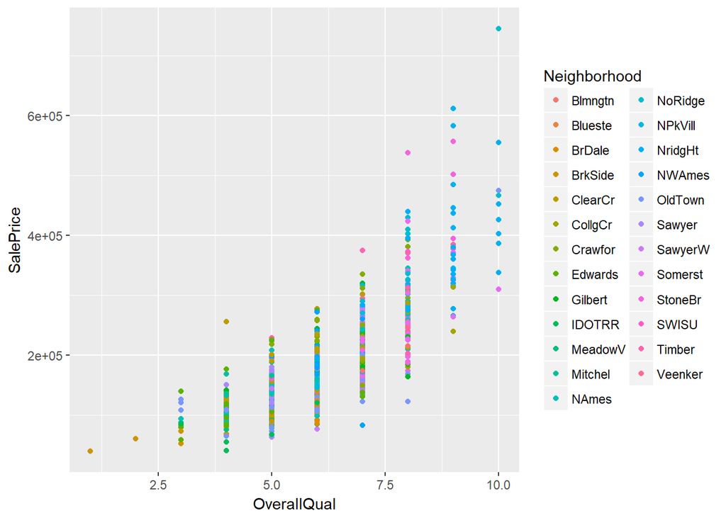

```r
# Plot relationship between sales price and OverallQual

ggplot(data=train_set)+
  geom_point(mapping = aes(x=OverallQual, y=SalePrice, color=Neighborhood))
```

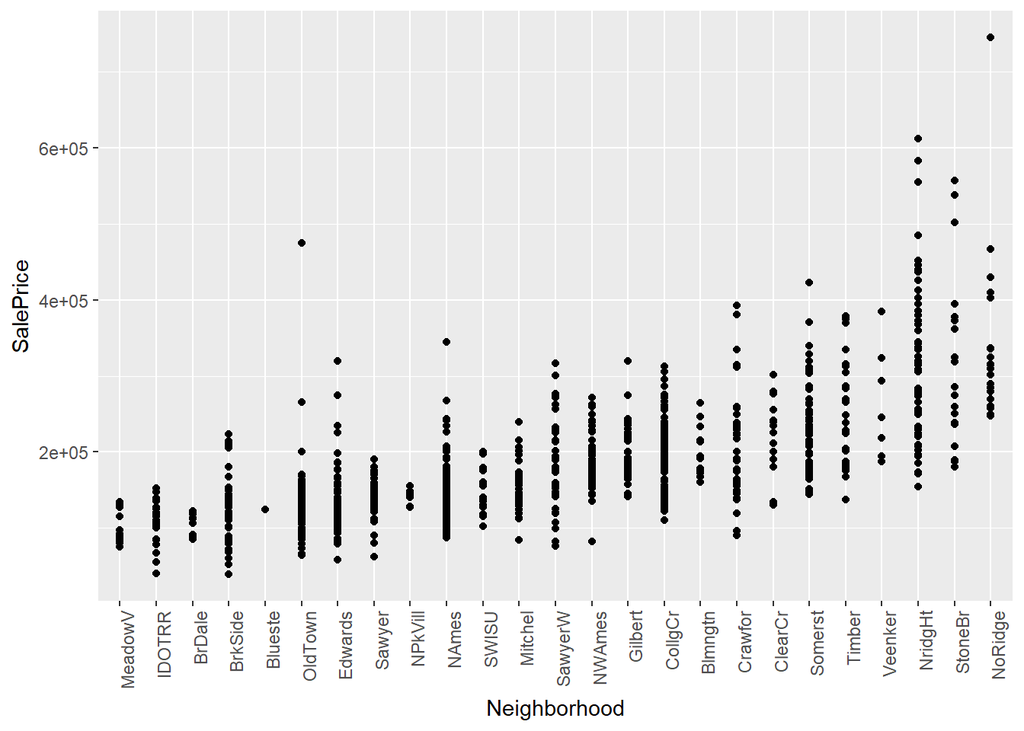

```r
# Plot relationship between sales price and OverallQual

ggplot(data=train_set)+
  geom_point(mapping = aes(x=reorder(Neighborhood,SalePrice, FUN=mean), y=SalePrice))+
  theme(axis.text.x = element_text(angle = 90, hjust = 1))+
  labs(x="Neighborhood")
```

```r
#Fit a regression model using GrLivArea, OverallQual, and Neighborhood as the features
mod_train_regr <- lm(SalePrice ~ GrLivArea + OverallQual + Neighborhood, data = train_set)

# Output coefficients
tidy(mod_train_regr)
```

```
##                   term     estimate    std.error  statistic      p.value
## 1          (Intercept) -45017.87483 12933.341808 -3.4807612 5.216927e-04
## 2            GrLivArea     62.77735     3.006033 20.8837885 1.337222e-80
## 3          OverallQual  21692.23178  1353.714104 16.0242342 1.389020e-51
## 4  NeighborhoodBlueste -38288.88063 36531.907177 -1.0480942 2.948497e-01
## 5   NeighborhoodBrDale -43314.05372 14524.693991 -2.9820975 2.932566e-03
## 6  NeighborhoodBrkSide -14064.37052 11318.850018 -1.2425618 2.143221e-01
## 7  NeighborhoodClearCr  27839.00662 13561.346871  2.0528202 4.035110e-02
## 8  NeighborhoodCollgCr   4297.67432 10372.304467  0.4143413 6.787135e-01
## 9  NeighborhoodCrawfor   7423.05573 11371.511784  0.6527765 5.140512e-01
## 10 NeighborhoodEdwards -15284.11495 10994.287187 -1.3901870 1.647830e-01
## 11 NeighborhoodGilbert  -8357.55930 10894.173472 -0.7671586 4.431692e-01
## 12  NeighborhoodIDOTRR -32689.43085 12603.712743 -2.5936350 9.636216e-03
## 13 NeighborhoodMeadowV -14446.06504 14190.148622 -1.0180348 3.089089e-01
## 14 NeighborhoodMitchel   1922.31487 11788.608170  0.1630655 8.705000e-01
## 15   NeighborhoodNAmes  -7719.67883 10375.956174 -0.7439969 4.570540e-01
## 16 NeighborhoodNoRidge  47685.16790 12567.432633  3.7943444 1.569690e-04
## 17 NeighborhoodNPkVill -20240.71145 16548.664867 -1.2231024 2.215806e-01
## 18 NeighborhoodNridgHt  63872.80848 10880.456671  5.8704161 5.917964e-09
## 19  NeighborhoodNWAmes -12279.33299 11047.502893 -1.1115030 2.666204e-01
## 20 NeighborhoodOldTown -36107.07577 10849.170903 -3.3280954 9.064637e-04
## 21  NeighborhoodSawyer  -4121.92502 11252.369778 -0.3663162 7.142070e-01
## 22 NeighborhoodSawyerW  -5391.97074 11230.758221 -0.4801075 6.312565e-01
## 23 NeighborhoodSomerst  18700.96725 10772.212794  1.7360377 8.286672e-02
## 24 NeighborhoodStoneBr  65712.45881 12745.312907  5.1558137 3.045915e-07
## 25   NeighborhoodSWISU -45451.86707 13564.792586 -3.3507233 8.363074e-04
## 26  NeighborhoodTimber  27925.08619 11985.325857  2.3299397 2.000859e-02
## 27 NeighborhoodVeenker  54913.12768 16521.075497  3.3238228 9.203087e-04
```

```r
# Output R-squared
glance(mod_train_regr)
```

```
##   r.squared adj.r.squared   sigma statistic p.value df    logLik      AIC
## 1 0.8099927     0.8050277 35178.1  163.1401       0 27 -12134.95 24325.91
##        BIC     deviance df.residual
## 1 24463.93 1.231311e+12         995
```

Coefficients on GrLivArea and OverallQual can be interpreted in the follwoing way: For every above grade (ground) living area square feet increase Sales Price of the house goes up by, an average, $62.78 and for every point increase in overall material and finish quality Sales Price increases by $21,692.

Coefficient on NeighborhoodBrkSide can be interprested as follows: Location of the house in BrkSide heighborhood decrease Sales Price by $14,064, on average.

GrLivArea and OverallQual are significant as supported by p-values that are close to 0. However, significance of Neighborhood varies, with majority of neightborhoods lacking significance.

All three features are practically significant. Wilingess to pay depends on the size of the house, the quality of the build and it’s location. However, neighborhoods could potentially be clustered into city regions to streamline the model.

This model is a fairly good fit to the training set since it explains roughly 81% of variability (R-squared).

### Exercise 5

Calculate RMSE from applying regression model to test set

```r
test_predictions <- predict(mod_train_regr, newdata = test_set)

rmse <- sqrt(mean(test_set$SalePrice - test_predictions)^2)
print(rmse)
```

```
## [1] 4567.101
```

Calculate RMSE from applying mean model to test set

```r
test_predictions <- predict(mod_0, newdata = test_set)

rmse <- sqrt(mean(test_set$SalePrice - test_predictions)^2)
print(rmse)
```

```
## [1] 4182.53
```

RMSE from mean model is smaller than RMSE from the regression model, implying overfitting of train data. Regression model has too much bias and, therefore, is not appropriate in this case.

### Exercise 6

```r
#Fit a regression model using GrLivArea, OverallQual, and YearBuilt as the features
mod_train_regr_b <- lm(SalePrice ~ GrLivArea + OverallQual + LotArea +KitchenQual, data = train_set)

# Output coefficients
tidy(mod_train_regr_b)
```

```
##            term      estimate    std.error   statistic      p.value
## 1   (Intercept)  7.449840e+03 1.004988e+04   0.7412865 4.586912e-01
## 2     GrLivArea  5.428155e+01 2.822156e+00  19.2340751 1.541175e-70
## 3   OverallQual  2.434120e+04 1.252393e+03  19.4357580 8.848847e-72
## 4       LotArea  9.534575e-01 1.021399e-01   9.3348163 6.185462e-20
## 5 KitchenQualFa -8.384553e+04 8.784587e+03  -9.5446180 9.817926e-21
## 6 KitchenQualGd -5.997931e+04 4.692222e+03 -12.7827086 8.431508e-35
## 7 KitchenQualTA -8.006403e+04 5.381279e+03 -14.8782529 1.939598e-45
```

```r
# Output R-squared
glance(mod_train_regr_b)
```

```
##   r.squared adj.r.squared   sigma statistic p.value df    logLik      AIC
## 1 0.8018185      0.800647 35571.1  684.4282       0  7 -12156.48 24328.95
##        BIC     deviance df.residual
## 1 24368.39 1.284283e+12        1015
```

Calculate RMSE from applying regression model to test set

```r
test_predictions <- predict(mod_train_regr_b, newdata = test_set)

rmse <- sqrt(mean(test_set$SalePrice - test_predictions)^2)
print(rmse)
```

```
## [1] 2208.589
```

Yeah!!!!! Kitchen quality matters - including Lot Area and Kitchen Quality explains 80% of variablity and produces 2208 (much smaller than mean) RMSE

### Exercise 7

Linear model is sensitive to unusual values. Intercept and x-coefficent changes given different slightly different data set, generated by the same model

```r
#generate data set

sim1a <- tibble(
  x = rep(1:10, each = 3),
  y = x * 1.5 + 6 + rt(length(x), df = 2)
)

#Fit a regression model using GrLivArea, OverallQual, and YearBuilt as the features
sim1a_regr <- lm(y ~ x, data = sim1a)

# Output coefficients
tidy(sim1a_regr)
```

```
##          term estimate std.error statistic      p.value
## 1 (Intercept) 6.694060 0.8711790  7.683909 2.270460e-08
## 2           x 1.456668 0.1404032 10.374889 4.244805e-11
```

```r
# Output R-squared
glance(sim1a_regr)
```

```
##   r.squared adj.r.squared    sigma statistic      p.value df    logLik
## 1 0.7935687     0.7861961 2.208842  107.6383 4.244805e-11  2 -65.30731
##        AIC      BIC deviance df.residual
## 1 136.6146 140.8182 136.6115          28
```

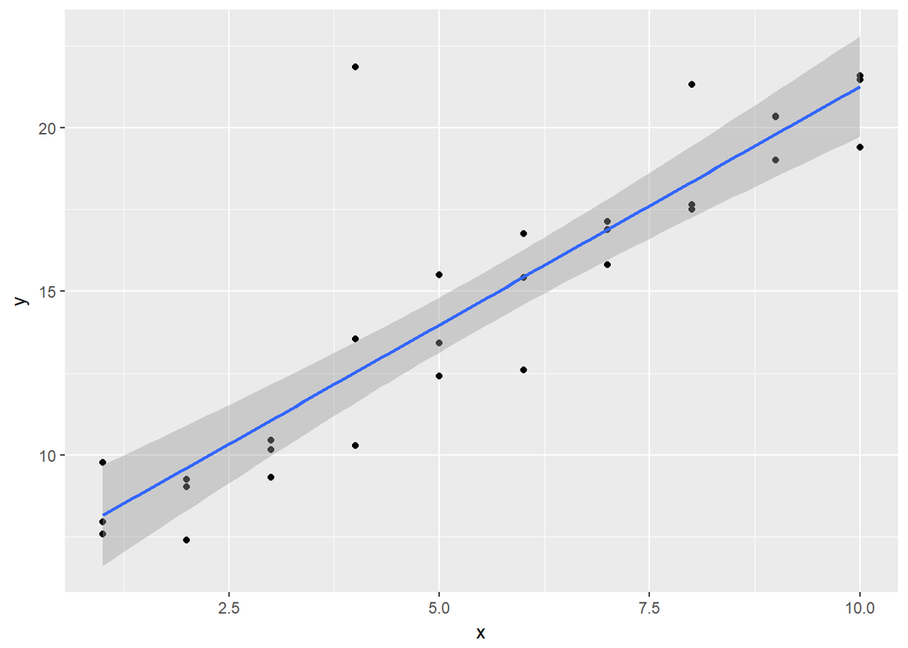

```r
ggplot(sim1a,aes(x=x, y=y))+
  geom_point()+
  geom_smooth(method='lm',formula=y ~ x)
```

```r
#generate data set

sim2a <- tibble(
  x = rep(1:10, each = 3),
  y = x * 1.5 + 6 + rt(length(x), df = 2)
)

#Fit a regression model using GrLivArea, OverallQual, and YearBuilt as the features
sim2a_regr <- lm(y ~ x, data = sim2a)

# Output coefficients
tidy(sim2a_regr)
```

```
##          term estimate std.error statistic      p.value
## 1 (Intercept) 5.246398 0.8619100  6.086944 1.448825e-06
## 2           x 1.539638 0.1389094 11.083761 9.471390e-12
```

```r
# Output R-squared
glance(sim2a_regr)
```

```
##   r.squared adj.r.squared    sigma statistic     p.value df    logLik
## 1 0.8143849     0.8077557 2.185341  122.8498 9.47139e-12  2 -64.98642
##        AIC      BIC deviance df.residual
## 1 135.9728 140.1764   133.72          28
```

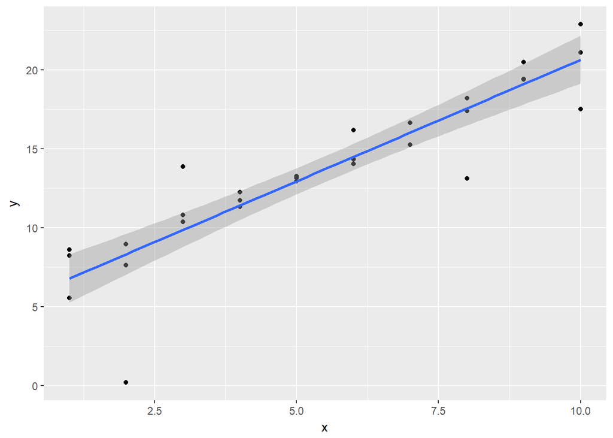

```r
ggplot(sim2a,aes(x=x, y=y))+
  geom_point()+
  geom_smooth(method='lm',formula=y ~ x)
```

```r
#generate data set

sim3a <- tibble(
  x = rep(1:10, each = 3),
  y = x * 1.5 + 6 + rt(length(x), df = 2)
)

#Fit a regression model using GrLivArea, OverallQual, and YearBuilt as the features
sim3a_regr <- lm(y ~ x, data = sim3a)

# Output coefficients
tidy(sim3a_regr)
```

```
##          term estimate std.error statistic      p.value
## 1 (Intercept) 6.288157 0.7594053   8.28037 5.198442e-09
## 2           x 1.373230 0.1223892  11.22019 7.146453e-12
```

```r
# Output R-squared
glance(sim3a_regr)
```

```
##   r.squared adj.r.squared    sigma statistic      p.value df    logLik
## 1 0.8180549     0.8115569 1.925444  125.8926 7.146453e-12  2 -61.18796
##        AIC      BIC deviance df.residual
## 1 128.3759 132.5795 103.8054          28
```

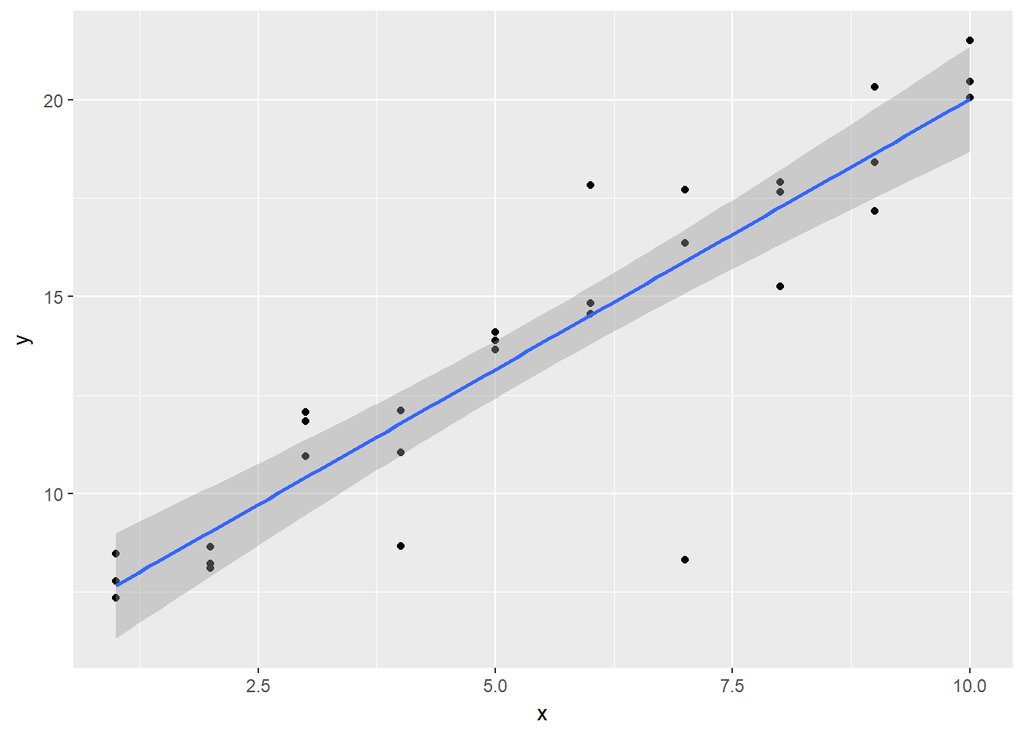

```r
ggplot(sim3a,aes(x=x, y=y))+
  geom_point()+
  geom_smooth(method='lm',formula=y ~ x)
```